# PA2_RepResearch

Andrew Moore

Tuesday, November 25, 2014

**Synopsis**

Major weather events often have immense tolls on both human life and economic activity. Weather events, natural disasters, and climate activity are some of the most widely recorded and extensive sources of data employed by modern society. These valuable records provide the ability to measure the cost of destructive natural events, and ultimately inform organizations and governments aiming to mitigate risks or participate in relief efforts. This analysis employs data maintained by the U.S. National Oceanic and Atmospheric Administration’s storm database. The included code retrieves and imports data from 1950-2011, summarizing human costs (measured by fatalities and injuries) and economic costs (measured through crop damage and economic damage) by event category. These analyses are performed at the aggregate (country level), in addition to analysis of regional variations in human and economic costs.

**Data Processing**

```r
library(dplyr)
```

```r
library(ggplot2)
library(gridExtra)
library(scales)
```

The data were accessed using a URL hyperlink. The dataset was provided in spreadsheet form, compressed as a bzfile. After downloading the file, variables of interest were chosen to be imported for analysis.

```r
url <- "http://d396qusza40orc.cloudfront.net/repdata%2Fdata%2FStormData.csv.bz2"

download.file(url, "repdata-data-StormData.csv.bz2")

vars <- rep("NULL", 37)
vars[c(2, 3, 7, 8, 37)] <- "factor"
vars[c(22:27)] <- "numeric"
vars[c(26, 28)] <- "character"

system.time(data <- read.csv(bzfile("repdata-data-StormData.csv.bz2"),
                             colClasses = vars, sep = ",", nrow = 902297))
```

```
##    user  system elapsed
##  276.73    1.91  283.45
```

After being imported, a subset was chosen to form the basis of the presented results. A key interest is the relationship between high cost on human life and economic damage. To accomplish this, the analysis included only events in which >25 fatalities or >50 injuries were reported. This resulted in a set of 436 events for analysis.

```r
subset <- filter(data, FATALITIES > 25 | INJURIES > 50)
```

Given the gradual evolution and modification of the NOAA Storm Database over time, event values/codes have been periodically added or modified. While coding distinctions lead to greater nuance when investigating specific categories of events, certain codes may be underpopulated or possibly redundant. To permit more simplified totals, certain variables were collapsed into more general categories (e.g. “EXCESSIVE HEAT” and “HEAT WAVE” were recategorized as merely “HEAT”).

```r
names(subset) <- toupper(names(subset)) ## all variables translated to uppercase to permit easier queries

heatstr <- grep("HEAT", subset$EVTYPE)
heatstr <- append(heatstr, grep("WARM", subset$EVTYPE))
subset$EVTYPE[heatstr] <- "HEAT"

fogstr <- grep("FOG", subset$EVTYPE)
subset$EVTYPE[fogstr] <- "FOG"

firestr <- grep("FIRE", subset$EVTYPE)
subset$EVTYPE[firestr] <- "FIRE"
wintstr <- grep("WINT", subset$EVTYPE)
wintstr <- append(wintstr, grep("ICE", subset$EVTYPE))
wintstr <- append(wintstr, grep("BLIZZARD", subset$EVTYPE))
wintstr <- append(wintstr, grep("SNOW", subset$EVTYPE))
wintstr <- append(wintstr, grep("COLD", subset$EVTYPE))
wintstr <- append(wintstr, grep("HAIL", subset$EVTYPE))
subset$EVTYPE[wintstr] <- "WINTER WEATHER"

floodstr <- grep("FLOOD", subset$EVTYPE)
subset$EVTYPE[floodstr] <- "FLOOD"

windstr <- grep("WIND", subset$EVTYPE)
subset$EVTYPE[windstr] <- "WIND"

rm(windstr, wintstr, floodstr, firestr, heatstr, fogstr)
```

Next, the subsetted data was organized into four separate datasets based on broad geographic regions of the U.S.

```r
## Organizing USA in to regions

uswest <- c("WA", "OR", "CA", "ID", "NV", "AZ", "MT", "WY", "CO", "NM", "AK")
ussouth <- c("TX", "OK", "AR", "LO", "MS", "AL", "FL", "GA", "KY", "TN", "VA",
             "WV", "DE", "MD", "NC", "SC")
usmidwest <- c("ND", "SD", "NE", "KS", "MN", "IA", "MO", "WI", "IL", "MI", "IN",
               "OH")
usnortheast <- c("MA", "NH", "VT", "MA", "RI", "CT", "NY", "PA", "CT", "NJ", "DC")

region <- c()
for (i in 1:nrow(subset)) {
    if (subset$STATE[i] %in% uswest) {
        region <- c(region, "west")
    } else {
        if (subset$STATE[i] %in% ussouth) {
            region <- c(region, "south")
        } else {
            if (subset$STATE[i] %in% usmidwest) {
                region <- c(region, "midwest")
            } else {
                if (subset$STATE[i] %in% usnortheast) {
                    region <- c(region, "northeast")
                } else {
                    region <- c(region, NA)
                }
            }
        }
    }
}

subset <- cbind(subset, region)
rm(usmidwest, usnortheast, ussouth, uswest)
```

Finally, in order to assess economic costs, the variables detailing damage amounts to property and crops needed to be adjusted. The variables were split between numeric values (e.g. “125”) and character strings (e.g. “K”), combining to form a categorical summary of an event’s cost (e.g. “125K” for $125,000). These columns were reprocessed and combined to form a more interpretable value. As with the choice regarding subsetting, this analysis is principally concerned with events that present the greatest aggregate harm. Thus, only values containing the “K”, “M”, and “B” strings (representing “thousands”, “millions”, and “billions” respectively) were included.

```r
econdat <- filter(subset, PROPDMGEXP == "K" | PROPDMGEXP == "M" | PROPDMGEXP == "B" | CROPDMGEXP == "K" | CROPDMGEXP == "M" | CROPDMGEXP == "B")

econdat$PROPDMGEXP[econdat$PROPDMGEXP == "K"] <- 1000
econdat$PROPDMGEXP[econdat$PROPDMGEXP == "M"] <- 1000000
econdat$PROPDMGEXP[econdat$PROPDMGEXP == "B"] <- 1000000000


econdat$CROPDMGEXP[econdat$CROPDMGEXP == "K"] <- 1000
econdat$CROPDMGEXP[econdat$CROPDMGEXP == "M"] <- 1000000
econdat$CROPDMGEXP[econdat$CROPDMGEXP == "B"] <- 1000000000

econdat <- mutate(econdat, propcost = PROPDMG * as.numeric(PROPDMGEXP))
econdat <- mutate(econdat, cropcost = CROPDMG * as.numeric(CROPDMGEXP))
```

**Results**

Before examining regional variation, aggregate totals for the U.S. were investigated. We first examined the impact on human life/health through the use of the FATALITIES and INJURIES variables.

```r
## Highest toll of fatalities
subset %.%
    group_by(EVTYPE) %.%
    summarise(total = sum(FATALITIES)) %.%
    arrange(desc(total)) %.%
    head(10)
```

```
## Source: local data frame [10 x 2]
##
##               EVTYPE total
## 1            TORNADO  2912
## 2               HEAT  1453
## 3              FLOOD    35
## 4            TSUNAMI    32
## 5                 NA    25
## 6  HURRICANE/TYPHOON    23
## 7     WINTER WEATHER    20
## 8                FOG     3
## 9     TROPICAL STORM     3
## 10              WIND     1
```

```r
## Highest toll of injuries
subset %.%
    group_by(EVTYPE) %.%
    summarise(total = sum(INJURIES)) %.%
    arrange(desc(total)) %.%
    head(10)
```

```
## Source: local data frame [10 x 2]
##
##               EVTYPE total
## 1            TORNADO 47841
## 2               HEAT  7246
## 3              FLOOD  6261
## 4     WINTER WEATHER  3518
## 5  HURRICANE/TYPHOON  1200
## 6               WIND   512
## 7                 NA   353
## 8     TROPICAL STORM   265
## 9                FOG   149
## 10           TSUNAMI   129
```

Based on this subset, tornados, high levels of heat, and flooding present the highest burden of injury and harm to human life. Tornados are the most highly reported event in the data. Without further documentation it’s unclear whether this represents incomplete records or some form of bias in reporting, but these data show tornados as representing the highest threat to human life. Hurricanes and tropical storms are another source of widescale destruction with high costs on human life, and it’s unclear why higher numbers of fatalities/injuries aren’t reported for these event type.

We next examined the trends in economic loss based on climate event. Having transformed the dollar amounts, these new totals were plotted based on the type of event.

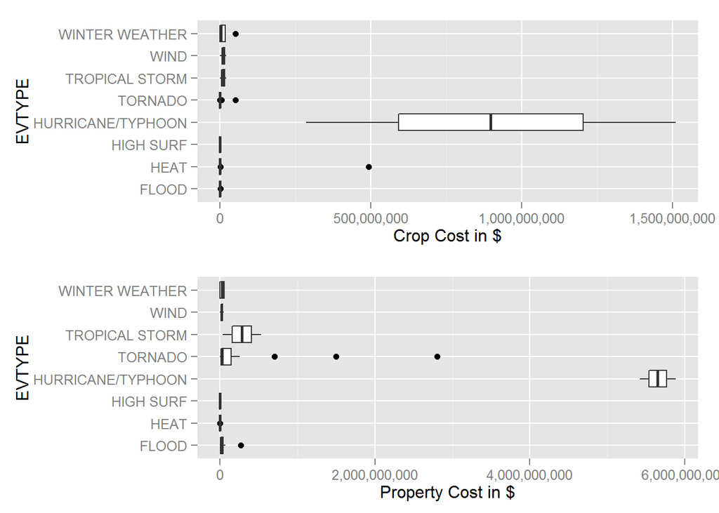

```r
p1 <- ggplot(na.omit(econdat), aes(x = EVTYPE, y = cropcost)) + geom_boxplot() + scale_y_continuous(label = comma, name = "Crop Cost in $") + coord_flip()
p2 <- ggplot(na.omit(econdat), aes(x = EVTYPE, y = propcost)) + geom_boxplot() + scale_y_continuous(label = comma, name = "Property Cost in $") + coord_flip()
grid.arrange(p1, p2, ncol = 1)
```

Potential reporting errors aside, another key question is which events present the greatest toll on human life and property as varied by region. Using the subsets defined by broad-geographic regions of the US, we reperformed the original analyses reported above.

```r
table(subset$region)
```

```
##
##   midwest northeast     south      west
##       148        33       231        14
```

```r
### Highest toll of fatalities ###
    ## West ##
filter(subset, region == "west") %.%
        group_by(EVTYPE) %.%
        summarise(west.total = sum(FATALITIES)) %.%
        arrange(desc(west.total)) %.%
        head(10)
```

```
## Source: local data frame [7 x 2]
##
##           EVTYPE west.total
## 1           HEAT         85
## 2             NA         25
## 3        TORNADO          7
## 4            FOG          2
## 5          FLOOD          0
## 6           WIND          0
## 7 WINTER WEATHER          0
```

```r
### Highest toll of fatalities ###
    ## Northeast ##
filter(subset, region == "northeast") %.%
            group_by(EVTYPE) %.%
            summarise(northeast.total = sum(FATALITIES)) %.%
            arrange(desc(northeast.total)) %.%
            head(10)
```

```
## Source: local data frame [5 x 2]
##
##           EVTYPE northeast.total
## 1           HEAT             335
## 2        TORNADO             135
## 3          FLOOD               3
## 4 WINTER WEATHER               3
## 5           WIND               1
```

```r
### Highest toll of fatalities ###
    ## South ##
filter(subset, region == "south") %.%
        group_by(EVTYPE) %.%
        summarise(south.total = sum(FATALITIES)) %.%
        arrange(desc(south.total)) %.%
        head(10)
```

```
## Source: local data frame [10 x 2]
##
##               EVTYPE south.total
## 1            TORNADO        1623
## 2               HEAT         128
## 3              FLOOD          32
## 4  HURRICANE/TYPHOON          22
## 5     WINTER WEATHER          13
## 6     TROPICAL STORM           3
## 7                FOG           1
## 8          HIGH SURF           0
## 9          LIGHTNING           0
## 10              WIND           0
```

```r
### Highest toll of fatalities ###
    ## Midwest ##
filter(subset, region == "midwest") %.%
        group_by(EVTYPE) %.%
        summarise(midwest.total = sum(FATALITIES)) %.%
        arrange(desc(midwest.total)) %.%
        head(10)
```

```
## Source: local data frame [6 x 2]
##
##           EVTYPE midwest.total
## 1        TORNADO          1114
## 2           HEAT           905
## 3 WINTER WEATHER             1
## 4          GLAZE             0
## 5      Heat Wave             0
## 6           WIND             0
```

```r
### Highest toll of injuries ###
    ## West ##
filter(subset, region == "west") %.%
       group_by(EVTYPE) %.%
       summarise(west.total = sum(INJURIES)) %.%
       arrange(desc(west.total)) %.%
       head(10)
```

```
## Source: local data frame [7 x 2]
##
##           EVTYPE west.total
## 1        TORNADO        378
## 2             NA        301
## 3           WIND        159
## 4           HEAT        120
## 5 WINTER WEATHER        118
## 6          FLOOD        116
## 7            FOG         78
```

```r
### Highest toll of injuries ###
    ## Northeast ##
filter(subset, region == "northeast") %.%
        group_by(EVTYPE) %.%
        summarise(northeast.total = sum(INJURIES)) %.%
        arrange(desc(northeast.total)) %.%
        head(10)
```

```
## Source: local data frame [5 x 2]
##
##           EVTYPE northeast.total
## 1        TORNADO            2683
## 2           HEAT             720
## 3 WINTER WEATHER             623
## 4          FLOOD             264
## 5           WIND             114
```

```r
### Highest toll of injuries ###
    ## South ##
filter(subset, region == "south") %.%
        group_by(EVTYPE) %.%
        summarise(south.total = sum(INJURIES)) %.%
        arrange(desc(south.total)) %.%
        head(10)
```

```
## Source: local data frame [10 x 2]
##
##               EVTYPE south.total
## 1            TORNADO       26866
## 2              FLOOD        5881
## 3               HEAT        1528
## 4     WINTER WEATHER         946
## 5  HURRICANE/TYPHOON         884
## 6     TROPICAL STORM         265
## 7               WIND         128
## 8                FOG          71
## 9          HIGH SURF          55
## 10                NA          52
```

```r
### Highest toll of injuries ###
    ## Midwest ##
filter(subset, region == "midwest") %.%
       group_by(EVTYPE) %.%
       summarise(midwest.total = sum(INJURIES)) %.%
       arrange(desc(midwest.total)) %.%
       head(10)
```

```
## Source: local data frame [6 x 2]
##
##           EVTYPE midwest.total
## 1        TORNADO         17127
## 2           HEAT          4878
## 3 WINTER WEATHER          1771
## 4           WIND           111
## 5      Heat Wave            70
## 6          GLAZE            61
```

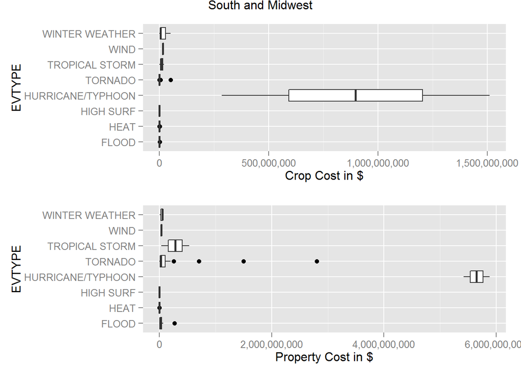

```r
p1 <- ggplot(na.omit(filter(econdat, region == "south" | region == "midwest")), aes(x = EVTYPE, y = cropcost)) + geom_boxplot() + scale_y_continuous(label = comma, name = "Crop Cost in $") + coord_flip()
p2 <- ggplot(na.omit(filter(econdat, region == "south" | region == "midwest")), aes(x = EVTYPE, y = propcost)) + geom_boxplot() + scale_y_continuous(label = comma, name = "Property Cost in $") + coord_flip()
grid.arrange(p1, p2, ncol = 1, main = "South and Midwest")
```

```r
### west, highest property damages
filter(na.omit(econdat), region == "west") %.%
       group_by(EVTYPE) %.%
       summarise(west.total = sum(propcost)) %.%
       arrange(desc(west.total)) %.%
       head(10)
```

```
## Source: local data frame [4 x 2]
##
##           EVTYPE west.total
## 1        TORNADO   1.47e+08
## 2           HEAT   1.70e+05
## 3           WIND   0.00e+00
## 4 WINTER WEATHER   0.00e+00
```

```r
### west, highest crop damages
filter(na.omit(econdat), region == "west") %.%
       group_by(EVTYPE) %.%
       summarise(west.total = sum(cropcost)) %.%
       arrange(desc(west.total)) %.%
       head(10)
```

```
## Source: local data frame [4 x 2]
##
##           EVTYPE west.total
## 1           HEAT  492400000
## 2        TORNADO          0
## 3           WIND          0
## 4 WINTER WEATHER          0
```

```r
### northeast, highest property damages
filter(na.omit(econdat), region == "northeast") %.%
       group_by(EVTYPE) %.%
       summarise(northeast.total = sum(propcost)) %.%
       arrange(desc(northeast.total)) %.%
       head(10)
```

```
## Source: local data frame [1 x 2]
##
##    EVTYPE northeast.total
## 1 TORNADO       455200000
```

```r
### northeast, highest crop damages
filter(na.omit(econdat), region == "northeast") %.%
       group_by(EVTYPE) %.%
       summarise(northeast.total = sum(cropcost)) %.%
       arrange(desc(northeast.total)) %.%
       head(10)
```

```
## Source: local data frame [1 x 2]
##
##    EVTYPE northeast.total
## 1 TORNADO               0
```

**Conclusions**

```r
with(na.omit(econdat), cor(propcost, FATALITIES))
```

```
## [1] 0.3508
```

```r
with(na.omit(econdat), cor(propcost, INJURIES))
```

```
## [1] 0.298
```

```r
with(na.omit(econdat), cor(cropcost, FATALITIES))
```

```
## [1] 0.1041
```

```r
with(na.omit(econdat), cor(cropcost, INJURIES))
```

```
## [1] -0.0346
```

Secondly, collapsing events categories in the manner the analysis used may be less optimal in finding good descriptive power. Nonetheless, the regional variation seems to generally reliable. Southern and midwestern states have a disproportionate risk for hurricane and tornado events, with markedly high costs in both human life and economic cost.